# EDA - Análise Exploratória de Dados

**Disciplina:** Tópicos Avançados em Inteligência Artificial  
**Aluno:** Diego Santos Seabra  
**Matrícula:** 0040251  
**Tema:** Jogos da Steam

## Dataset

Para esta análise exploratória de dados, foi-se utilizado um dataset público, disponível no [Kaggle](https://www.kaggle.com/jesneuman/pc-games), cujo conteúdo apresenta dados de jogos da plataforma Steam (Steam é uma plataforma de venda de jogos digitais). O dataset foi lido através do arquivo 'games.csv'.

## Objetivo

O principal objetivo com este EDA era o de comparar os jogos indie com os jogos AAA.

## Descrição das Variáveis

- Metacritic (Nota do jogo na plataforma metacritic)
- Genres (Gêneros associados com este jogo)
- Indie (Se o jogo é indie ou não >> boleano)
- Presence (Número total de 'artigos' em redes sociais, ex.: Reddit)
- Platform (Plataformas em que o jogo foi lançado)
- OriginalCost (Custo original do jogo, ou preço de venda)
- Players (Modo de jogo >> single player, multiplayer, etc)
- Controller (Se o jogo pode ser jogado com um gamepad ou não >> boleano)
- Languages (Idiomas em que o jogo pode ser jogado)
- ESRB (Classificação ESRB)
- Achievements (Número de conquistas disponíveis em um jogo)

## Limpeza dos Dados

Antes de se realizar o EDA, foi-se necessária a limpeza dos dados do dataset. Algumas colunas apresentavam dados 'NaN' e outra colunas não eram úteis para a análise em questão.

Estas colunas em questão foram removidas:

- RawgID
- SteamURL
- RatingsBreakdown
- Soundtrack
- Franchise
- DiscountedCost
- Publisher
- Graphics
- Storage
- Memory
- Tags
- Description

As outras colunas do dataset foram mantidas.

```python
# Imports
import pandas as pd
import numpy as np
import seaborn as sns
import matplotlib.pyplot as plt
from scipy.stats import norm
```

```python
# Lê o arquivo csv
df = pd.read_csv('games.csv')

# Remove os NaN (para evitar erros)
df.dropna(inplace=True)
```

```python
# Se necessário, cria uma amostra com um pedaço do dataset
# smp = df.sample(500)
# Aqui estarei usando o dataset por inteiro
smp = df
```

```python
smp.head()
```

|  | id | Name | Metacritic | Genres | Indie | Presence | Platform | ReleaseDate | OriginalCost | Players | Controller | Languages | ESRB | Achievements |
| --- | --- | --- | --- | --- | --- | --- | --- | --- | --- | --- | --- | --- | --- | --- |
| 0 | 1 | Counter-Strike: Global Offensive | 83.0 | Action, Free to Play | 0.0 | 1009588.0 | PC, Xbox 360, PlayStation 3 | 2012-08-21 | Free to Play | multiplayer, pvp, coop, online coop | 1.0 | English, Czech, Danish, Dutch, Finnish, French... | Mature | 179.0 |
| 1 | 2 | Destiny 2 | 82.0 | Action, Adventure, Free to Play | 0.0 | 1007425.0 | PlayStation 5, Web, Xbox Series X, PC, Xbox On... | 2017-09-06 | Free To Play | multiplayer, coop, online coop | 1.0 | English, French, Italian, German, Japanese, Ko... | Teen | 61.0 |
| 4 | 5 | Sea of Thieves | 68.0 | Action, Adventure | 0.0 | 777456.0 | PC, Xbox One | 2018-03-20 | $39.99 | multiplayer, pvp, coop, online coop | 1.0 | English, French, Italian, German, Russian | Teen | 308.0 |
| 6 | 7 | Tom Clancy's Rainbow Six Siege | 75.0 | Action | 0.0 | 1001424.0 | PlayStation 4, PC, Xbox One | 2015-12-01 | $19.99 | singleplayer, multiplayer, coop, online coop | 1.0 | English, French, Italian, German, Czech, Dutch... | Mature | 82.0 |
| 7 | 8 | Rocket League | 86.0 | Action, Indie, Racing, Sports | 1.0 | 1006678.0 | Linux, macOS, PC, PlayStation 4, Xbox One, Nin... | 2015-07-07 | $19.99 | singleplayer, multiplayer, coop, online coop | 1.0 | English, French, Italian, German, Dutch, Portu... | Everyone | 253.0 |

Alguns valores, como o 'OriginalCost' possuíam o '$' em sua string e foi necessária a sua remoção

```python
# Corrigindo os valores da coluna 'OriginalCost'
smp['OriginalCost'] = smp['OriginalCost'].str.replace('$','')
costTerms = ['Free', 'free', 'Demo', 'demo', 'Party', 'party', 'try', 'Try', 'Trial', 'trial', 'DEMO', 'Play', 'play', 'pass', 'buddy', 'Buddy', 'UNO']
costContainer = smp['OriginalCost'].str.contains('|'.join(costTerms), na=False)
smp.loc[costContainer, 'OriginalCost'] = '0.00'
```

Também foram criadas novas colunas no dataset, afim de quantificar:

- Número de Idiomas
- Número de Plataformas
- Número de Gêneros
- Número de Modos de Jogo

```python
# Cálculos dos números de categorias
def countQte(x):
    return len(x.split(','))

# Calculando a quantidade de idiomas
smp['nLanguages'] = smp['Languages'].apply(lambda x: countQte(x))
# Calculando a quantidade de plataformas
smp['nPlatforms'] = smp['Platform'].apply(lambda x: countQte(x))
# Calculando a quantidade de gêneros
smp['nGenres'] = smp['Genres'].apply(lambda x: countQte(x))
# Calculando a quantidade de modos de jogo
smp['nPlayers'] = smp['Players'].apply(lambda x: countQte(x))
```

Foram empregadas mais algumas correções nas colunas 'Indie' e 'OriginalCost', para acertar o tipo de dados das mesmas

```python
# Correção dos tipos das colunas
smp = smp.astype({'Indie': bool, 'OriginalCost': float})
```

## Correlação de Dados

Uma das informações mais interessantes entre as variáveis de um dataset é a correlação entre essas variáveis. Na estatística, usamos a correlação para identificar a interdependência entre duas ou mais variáveis e portanto, foi aplicada abaixo.

```python
# Cria um dataframe para a correlação de dados (faz o drop do id pois não é importante)
corrData = smp.corr()
corrData = corrData.drop('id', 0)
corrData = corrData.drop('id', 1)
corrData
```

|  | Metacritic | Indie | Presence | OriginalCost | Controller | Achievements | nLanguages | nPlatforms | nGenres | nPlayers |
| --- | --- | --- | --- | --- | --- | --- | --- | --- | --- | --- |
| Metacritic | 1.000000 | -0.058499 | 0.189542 | 0.078827 | -0.039166 | 0.101042 | 0.064553 | 0.197477 | -0.063375 | 0.047073 |
| Indie | -0.058499 | 1.000000 | -0.261363 | -0.289052 | 0.009061 | -0.173863 | -0.046311 | 0.154950 | 0.485173 | -0.253658 |
| Presence | 0.189542 | -0.261363 | 1.000000 | 0.097730 | 0.028020 | 0.269758 | 0.153851 | 0.091183 | -0.063038 | 0.221454 |
| OriginalCost | 0.078827 | -0.289052 | 0.097730 | 1.000000 | 0.302628 | 0.307741 | 0.234652 | -0.007082 | -0.177916 | 0.232563 |
| Controller | -0.039166 | 0.009061 | 0.028020 | 0.302628 | 1.000000 | 0.284224 | 0.151194 | 0.219157 | 0.030955 | 0.116139 |
| Achievements | 0.101042 | -0.173863 | 0.269758 | 0.307741 | 0.284224 | 1.000000 | 0.189371 | 0.252577 | -0.020249 | 0.253695 |
| nLanguages | 0.064553 | -0.046311 | 0.153851 | 0.234652 | 0.151194 | 0.189371 | 1.000000 | 0.069636 | 0.026536 | 0.204611 |
| nPlatforms | 0.197477 | 0.154950 | 0.091183 | -0.007082 | 0.219157 | 0.252577 | 0.069636 | 1.000000 | 0.065674 | -0.043399 |
| nGenres | -0.063375 | 0.485173 | -0.063038 | -0.177916 | 0.030955 | -0.020249 | 0.026536 | 0.065674 | 1.000000 | -0.068395 |
| nPlayers | 0.047073 | -0.253658 | 0.221454 | 0.232563 | 0.116139 | 0.253695 | 0.204611 | -0.043399 | -0.068395 | 1.000000 |

Demonstrando a correlação em um heatmap, temos:

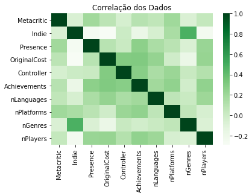

```python
# Criando a matriz de correlação dos dados
sns.heatmap(corrData, cmap='Greens')
plt.title('Correlação dos Dados')
plt.show()
```

Após uma primeira análise à este heatmap, é possível perceber que algumas variáveis parecem estarem correlacionadas, sendo elas:

- Jogos indies *vs.* número de gêneros
- Custo do jogo *vs.* número de achievements
- Nota no metacritic *vs.* número de plataformas
- Custo do jogo *vs.* se o jogo permite ser jogado com um controle
- Nota no metacritic *vs.* presença nas redes sociais

## Distribuição das Variáveis

É interessante, também, saber a distribuição (em forma de histograma) das variáveis deste dataset e, portanto:

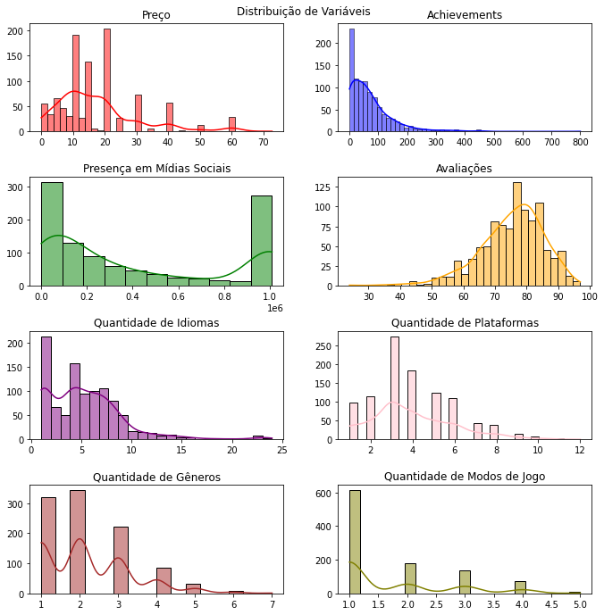

```python
# Distribuições de Variáveis
fig, ax = plt.subplots(4,2,figsize=(10,10))
fig.tight_layout(pad=3.0)
# plt.subplots_adjust(bottom=0.1,top=0.92,left=0.1)
fig.suptitle('Distribuição de Variáveis')
sns.histplot(data=smp['OriginalCost'], ax=ax[0][0], kde=True, color='red')
ax[0][0].set(title='Preço',ylabel='',xlabel='')
sns.histplot(data=smp['Achievements'], ax=ax[0][1], kde=True, color='blue')
ax[0][1].set(title='Achievements',ylabel='',xlabel='')
sns.histplot(data=smp['Presence'], ax=ax[1][0], kde=True, color='green')
ax[1][0].set(title='Presença em Mídias Sociais',ylabel='',xlabel='')
sns.histplot(data=smp['Metacritic'], ax=ax[1][1], kde=True, color='orange')
ax[1][1].set(title='Avaliações',ylabel='',xlabel='')
sns.histplot(data=smp['nLanguages'], ax=ax[2][0], kde=True, color='purple')
ax[2][0].set(title='Quantidade de Idiomas',ylabel='',xlabel='')
sns.histplot(data=smp['nPlatforms'], ax=ax[2][1], kde=True, color='pink')
ax[2][1].set(title='Quantidade de Plataformas',ylabel='',xlabel='')
sns.histplot(data=smp['nGenres'], ax=ax[3][0], kde=True, color='brown')
ax[3][0].set(title='Quantidade de Gêneros',ylabel='',xlabel='')
sns.histplot(data=smp['nPlayers'], ax=ax[3][1], kde=True, color='olive')
ax[3][1].set(title='Quantidade de Modos de Jogo',ylabel='',xlabel='')
plt.show()
```

## Comparação entre jogos indies e AAA

Nesta seção, tenta-se responder algumas perguntas comparando os jogos entre as categorias 'Indie' e 'AAA':

- Jogos indies são mais caros que os AAA?
- Qual das duas categorias possui melhores avaliações no Metacritic?
- Qual categoria possui mais achievements?
- Qual categoria possui maior presença nas redes sociais?

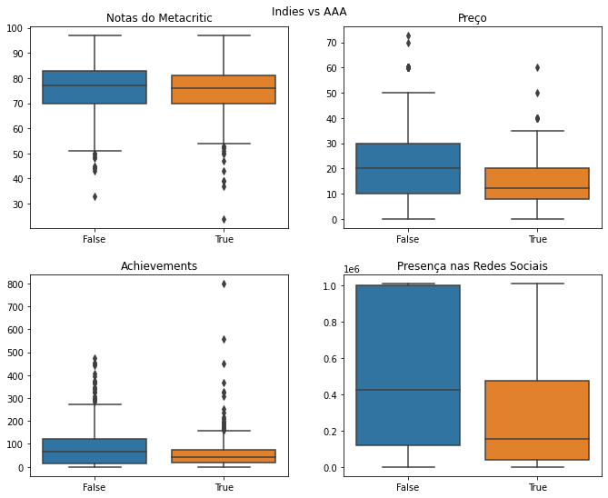

```python
# Comparação Indie vs AAA
fig, ax = plt.subplots(2,2,figsize=(10,8))
fig.tight_layout(pad=3.0)
# plt.subplots_adjust(bottom=0.1,top=0.92,left=0.1)
fig.suptitle('Indies vs AAA')
sns.boxplot(data=smp, x='Indie', y='Metacritic', ax=ax[0][0])
ax[0][0].set(title='Notas do Metacritic',ylabel='',xlabel='')
sns.boxplot(data=smp, x='Indie', y='OriginalCost', ax=ax[0][1])
ax[0][1].set(title='Preço',ylabel='',xlabel='')
sns.boxplot(data=smp, x='Indie', y='Achievements', ax=ax[1][0])
ax[1][0].set(title='Achievements',ylabel='',xlabel='')
sns.boxplot(data=smp, x='Indie', y='Presence', ax=ax[1][1])
ax[1][1].set(title='Presença nas Redes Sociais',ylabel='',xlabel='')
plt.show()
```

Dos gráficos apresentados acima, pode-se perceber que:

- As avaliações entre jogos indie e jogos AAA são praticamente iguais
- Jogos indie em um geral custam menos que jogos AAA
- Jogos indie possuem menos achievements (em média) que os rivais AAA, porém possuem mais outliers, ou seja, alguns jogos indie possuem muitos achievements
- A maioria dos jogos AAA possuem maior presença em redes sociais. Isto pode ser devido ao grande investimento com *marketing* que as grandes corporações aplicam para adquirir mais jogadores
- Existe um jogo Indie (outlier) que possui a menor nota do dataset
- Existe um jogo AAA (outlier) que possui o maior preço do dataset

Uma avaliação interessante pode ser feita aqui:

Jogos indie, mesmo não possuindo grandes presenças em redes sociais (provavelmente com pouco investimento em marketing) e sendo normalmente mais baratos (em comparação com os AAA) conseguiram uma média de avaliações praticamente igual aos do AAA (com exceção dos outliers indie que foram extremamente mal avaliados)

## Avaliações

- Quais são os piores jogos? Quais os melhores?
- Qual o jogo mais bem avaliado? Qual o pior? E os indies?
- Qual o jogo mais caro?

### Jogo mais bem avaliado

```python
# Jogo mais bem avaliado
smp.sort_values(by='Metacritic', ascending=False).head(1)
```

|  | id | Name | Metacritic | Genres | Indie | Presence | Platform | ReleaseDate | OriginalCost | Players | Controller | Languages | ESRB | Achievements | nLanguages | nPlatforms | nGenres | nPlayers |
| --- | --- | --- | --- | --- | --- | --- | --- | --- | --- | --- | --- | --- | --- | --- | --- | --- | --- | --- |
| 10 | 11 | Grand Theft Auto V | 97.0 | Action, Adventure | False | 1004912.0 | PlayStation 5, PC, PlayStation 4, PlayStation ... | 2013-09-17 | 29.99 | singleplayer, multiplayer, coop | 1.0 | English, French, Italian, German, Korean, Poli... | Mature | 369.0 | 8 | 6 | 2 | 3 |

### Jogo com pior avaliação

```python
# Jogo com pior avaliação
smp.sort_values(by='Metacritic', ascending=True).head(1)
```

|  | id | Name | Metacritic | Genres | Indie | Presence | Platform | ReleaseDate | OriginalCost | Players | Controller | Languages | ESRB | Achievements | nLanguages | nPlatforms | nGenres | nPlayers |
| --- | --- | --- | --- | --- | --- | --- | --- | --- | --- | --- | --- | --- | --- | --- | --- | --- | --- | --- |
| 21089 | 21090 | Postal III | 24.0 | Action | True | 152640.0 | PC | 2012-02-17 | 11.99 | singleplayer, multiplayer | 0.0 | English, Russian, German | Mature | 38.0 | 3 | 1 | 1 | 2 |

### Top 5 jogos mais bem avaliados

```python
# Top 5 jogos mais bem avaliados
smp.sort_values(by='Metacritic', ascending=False).head(5)
```

|  | id | Name | Metacritic | Genres | Indie | Presence | Platform | ReleaseDate | OriginalCost | Players | Controller | Languages | ESRB | Achievements | nLanguages | nPlatforms | nGenres | nPlayers |
| --- | --- | --- | --- | --- | --- | --- | --- | --- | --- | --- | --- | --- | --- | --- | --- | --- | --- | --- |
| 10 | 11 | Grand Theft Auto V | 97.0 | Action, Adventure | False | 1004912.0 | PlayStation 5, PC, PlayStation 4, PlayStation ... | 2013-09-17 | 29.99 | singleplayer, multiplayer, coop | 1.0 | English, French, Italian, German, Korean, Poli... | Mature | 369.0 | 8 | 6 | 2 | 3 |
| 20083 | 20084 | Grand Theft Auto V | 97.0 | Free to Play, Indie, Massively Multiplayer, St... | True | 1004912.0 | PlayStation 5, PC, PlayStation 4, PlayStation ... | 2013-09-17 | 0.00 | multiplayer | 0.0 | English, Russian | Mature | 369.0 | 2 | 6 | 4 | 1 |
| 15 | 16 | Red Dead Redemption 2 | 97.0 | Action, Adventure | False | 1004105.0 | PC, Xbox One, PlayStation 4 | 2018-10-26 | 59.99 | singleplayer, multiplayer | 1.0 | English, French, Italian, German, Japanese, Ko... | Mature | 118.0 | 9 | 3 | 2 | 2 |
| 753 | 754 | BioShock | 96.0 | Action, RPG | False | 1002857.0 | Xbox One, PC, PlayStation 4, PlayStation 3, ma... | 2007-08-21 | 19.99 | singleplayer | 1.0 | English, French, German, Italian | Mature | 375.0 | 4 | 7 | 2 | 1 |
| 146 | 147 | Portal 2 | 95.0 | Action, Adventure | False | 1006285.0 | PlayStation 3, PC, Xbox 360, Linux, macOS | 2011-04-19 | 9.99 | coop | 1.0 | English, French, German, Czech, Danish, Dutch,... | Everyone 10+ | 152.0 | 19 | 5 | 2 | 1 |

### Top 5 jogos mais caros

```python
# Top 5 jogos mais caros
smp.sort_values(by='OriginalCost', ascending=False).head(5)
```

|  | id | Name | Metacritic | Genres | Indie | Presence | Platform | ReleaseDate | OriginalCost | Players | Controller | Languages | ESRB | Achievements | nLanguages | nPlatforms | nGenres | nPlayers |
| --- | --- | --- | --- | --- | --- | --- | --- | --- | --- | --- | --- | --- | --- | --- | --- | --- | --- | --- |
| 6323 | 6324 | Sleeping Dogs | 81.0 | Action, Adventure | False | 1001518.0 | Xbox 360, PC, PlayStation 3 | 2012-08-14 | 72.77 | singleplayer | 1.0 | English, French, German, Italian, Russian, Polish | Mature | 192.0 | 6 | 3 | 2 | 1 |
| 103 | 104 | Need for Speed Heat | 73.0 | Action, Adventure, Racing, Sports | False | 667277.0 | Xbox One, PlayStation 4, PC | 2019-11-08 | 69.99 | singleplayer, multiplayer, pvp, coop, online coop | 1.0 | English, French, Italian, German, Korean, Arab... | Teen | 65.0 | 9 | 3 | 4 | 5 |
| 64 | 65 | DOOM Eternal | 88.0 | Action | False | 31723.0 | PC, Nintendo Switch, PlayStation 4, Xbox One | 2020-03-20 | 59.99 | singleplayer, multiplayer | 1.0 | English, French, Italian, German, Japanese, Ko... | Mature | 81.0 | 8 | 4 | 1 | 2 |
| 164 | 165 | Call of Duty: Black Ops II | 74.0 | Action | False | 1001917.0 | PlayStation 3, PC, Xbox 360, Xbox One, Wii U | 2012-11-13 | 59.99 | singleplayer, multiplayer, coop, online coop | 1.0 | English, French, German, Italian | Mature | 216.0 | 4 | 5 | 1 | 4 |
| 51 | 52 | Call of Duty: Black Ops III | 73.0 | Action, Adventure | False | 1002053.0 | PC, PlayStation 4, Xbox 360, Xbox One, PlaySta... | 2015-11-06 | 59.99 | singleplayer, multiplayer, coop | 1.0 | English, French, Italian, German, Japanese, Po... | Mature | 347.0 | 7 | 5 | 2 | 3 |

### Top 5 jogos com mais achievements

```python
# Top 5 jogos com mais achievements
smp.sort_values(by='Achievements', ascending=False).head(5)
```

|  | id | Name | Metacritic | Genres | Indie | Presence | Platform | ReleaseDate | OriginalCost | Players | Controller | Languages | ESRB | Achievements | nLanguages | nPlatforms | nGenres | nPlayers |
| --- | --- | --- | --- | --- | --- | --- | --- | --- | --- | --- | --- | --- | --- | --- | --- | --- | --- | --- |
| 2026 | 2027 | One Finger Death Punch 2 | 81.0 | Action, Casual, Indie | 1.0 | 115644.0 | PC, Xbox One, Nintendo Switch | 2019-04-14 | 7.99 | singleplayer, coop | 1.0 | English | Teen | 800.0 | 1 | 3 | 3 | 2 |
| 189 | 190 | The Binding of Isaac: Rebirth | 86.0 | Action | 1.0 | 970552.0 | PC, iOS, Nintendo 3DS, macOS, Linux, Wii U, PS... | 2014-11-04 | 14.99 | singleplayer, coop | 1.0 | English | Mature | 557.0 | 1 | 10 | 1 | 2 |
| 206 | 207 | Neverwinter | 74.0 | Adventure, Free to Play, Massively Multiplayer... | 0.0 | 1001196.0 | PC, Xbox One, PlayStation 4 | 2013-06-20 | 0.00 | multiplayer, pvp, coop | 0.0 | English, French, Italian, German, Polish, Turk... | Teen | 476.0 | 7 | 3 | 4 | 3 |
| 13 | 14 | Warframe | 70.0 | Action, Free to Play | 0.0 | 1009230.0 | Xbox Series X, PlayStation 5, PC, Nintendo Swi... | 2013-03-25 | 0.00 | singleplayer, multiplayer, coop, online coop | 1.0 | English, German, French, Italian, Korean, Russ... | Mature | 454.0 | 10 | 6 | 2 | 4 |
| 506 | 507 | Plague Inc: Evolved | 80.0 | Casual, Indie, Simulation, Strategy | 1.0 | 393630.0 | Nintendo Switch, Linux, macOS, PC, Xbox One, P... | 2015-09-18 | 14.99 | singleplayer, multiplayer, coop | 1.0 | English, French, German, Russian, Italian, Por... | Everyone 10+ | 449.0 | 11 | 6 | 4 | 3 |

### Top 5 jogos com mais presença em redes sociais

```python
# Top 5 jogos com mais achievements
smp.sort_values(by='Presence', ascending=False).head(5)
```

|  | id | Name | Metacritic | Genres | Indie | Presence | Platform | ReleaseDate | OriginalCost | Players | Controller | Languages | ESRB | Achievements | nLanguages | nPlatforms | nGenres | nPlayers |
| --- | --- | --- | --- | --- | --- | --- | --- | --- | --- | --- | --- | --- | --- | --- | --- | --- | --- | --- |
| 0 | 1 | Counter-Strike: Global Offensive | 83.0 | Action, Free to Play | 0.0 | 1009588.0 | PC, Xbox 360, PlayStation 3 | 2012-08-21 | 0.00 | multiplayer, pvp, coop, online coop | 1.0 | English, Czech, Danish, Dutch, Finnish, French... | Mature | 179.0 | 23 | 3 | 2 | 4 |
| 469 | 470 | Mass Effect 2 | 94.0 | RPG | 0.0 | 1009410.0 | PC, PlayStation 3, Xbox 360 | 2010-01-26 | 19.99 | singleplayer | 0.0 | English, French, German, Czech, Hungarian, Ita... | Mature | 121.0 | 8 | 3 | 1 | 1 |
| 13 | 14 | Warframe | 70.0 | Action, Free to Play | 0.0 | 1009230.0 | Xbox Series X, PlayStation 5, PC, Nintendo Swi... | 2013-03-25 | 0.00 | singleplayer, multiplayer, coop, online coop | 1.0 | English, German, French, Italian, Korean, Russ... | Mature | 454.0 | 10 | 6 | 2 | 4 |
| 486 | 487 | Mass Effect | 89.0 | Action, RPG | 0.0 | 1009056.0 | PC, PlayStation 3, Xbox 360 | 2007-11-16 | 19.99 | singleplayer | 0.0 | English, French, German, Italian | Mature | 96.0 | 4 | 3 | 2 | 1 |
| 14 | 15 | Monster Hunter: World | 89.0 | Action | 0.0 | 1008752.0 | PlayStation 4, PC, Xbox One | 2018-01-26 | 29.99 | singleplayer, multiplayer, coop | 1.0 | English, French, Italian, German, Arabic, Poli... | Teen | 178.0 | 9 | 3 | 1 | 3 |

```python
# Separa os jogos indie em um outro dataframe
indies = smp.loc[smp['Indie'] == True]
```

### Top 5 jogos indies mais caros

```python
# Top 5 jogos indies mais caros
indies.sort_values(by='OriginalCost', ascending=False).head(5)
```

|  | id | Name | Metacritic | Genres | Indie | Presence | Platform | ReleaseDate | OriginalCost | Players | Controller | Languages | ESRB | Achievements | nLanguages | nPlatforms | nGenres | nPlayers |
| --- | --- | --- | --- | --- | --- | --- | --- | --- | --- | --- | --- | --- | --- | --- | --- | --- | --- | --- |
| 526 | 527 | We Happy Few | 64.0 | Action, Adventure, Indie | True | 612944.0 | PC, PlayStation 4, Xbox One | 2018-08-09 | 59.99 | singleplayer | 1.0 | English, French, Italian, German, Japanese, Ru... | Mature | 179.0 | 6 | 3 | 3 | 1 |
| 988 | 989 | Disintegration | 63.0 | Action, Adventure | True | 539.0 | PlayStation 4, Xbox One, PC | 2020-06-16 | 49.99 | singleplayer, multiplayer, pvp | 1.0 | English, French, Italian, German, Russian | Teen | 75.0 | 5 | 3 | 2 | 3 |
| 922 | 923 | Indivisible | 79.0 | Action, Indie, RPG | True | 77300.0 | PC, macOS, Xbox One, PlayStation 4, Linux, Nin... | 2019-10-07 | 39.99 | singleplayer | 1.0 | English, French, Italian, German, Korean, Russ... | Everyone | 50.0 | 7 | 6 | 3 | 1 |
| 47 | 48 | Disco Elysium | 91.0 | RPG | True | 52433.0 | PC | 2019-10-14 | 39.99 | singleplayer | 0.0 | English | Mature | 21.0 | 1 | 1 | 1 | 1 |
| 355 | 356 | Divinity: Original Sin - Enhanced Edition | 94.0 | Adventure, Indie, RPG, Strategy | True | 180413.0 | macOS, Linux, Xbox One, PlayStation 4, PC | 2015-10-27 | 39.99 | singleplayer, multiplayer, coop | 1.0 | English, French, Italian, German, Russian, Pol... | Mature | 108.0 | 8 | 5 | 4 | 3 |

### Distribuição dos Preços por ESRB Rating

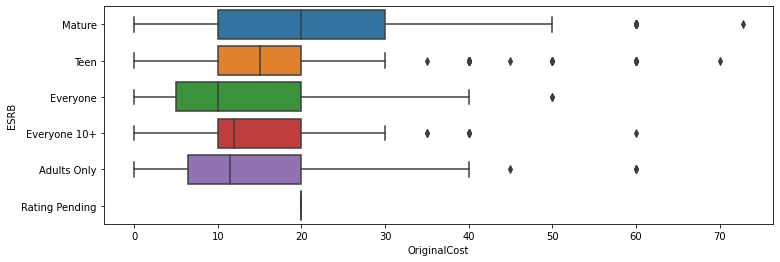

```python
# ESRB
plt.figure(figsize=(12,4))
sns.boxplot(data=smp, x='OriginalCost', y='ESRB')
plt.show()
```

### Distribuição dos Preços em cada Gênero

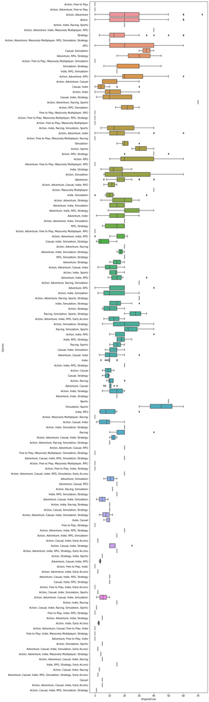

```python
# Distribuição dos Preços em cada Gênero
plt.figure(figsize=(12,40))
sns.boxplot(data=smp, x='OriginalCost', y='Genres')
plt.tight_layout()
plt.show()
```

### Variação do Preço no Ano de 2020

[figure not shown]

```python
# Variação do preço no ano de 2020
jogos2020 = smp.loc[smp['ReleaseDate'] >= '2020-01-01']
jogos2020 = jogos2020.sort_values(by='ReleaseDate', ascending=True)
fig, ax = plt.subplots(figsize=(10,4))
sns.lineplot(data=jogos2020, x='ReleaseDate', y='OriginalCost', ax=ax)
plt.ylabel('Preço')
plt.xlabel('Data')
plt.xticks(rotation=30)
plt.title('Variação do Preço no Ano de 2020')
plt.show()
```